# LaLigaDataAnalysis

Students: Sofia Almirante: 1527718 \ Sergi Picó: 1521767 \ Pau Reig: 1527816

```python
import pandas as pd
import numpy as np
import sqlite3
import matplotlib.pyplot as plt
pd.set_option('mode.chained_assignment', None)

con = sqlite3.connect('laliga.sqlite')
sql_query = pd.read_sql("SELECT * FROM Matches", con)

df = pd.DataFrame(sql_query, columns = ['season', 'division', 'matchday','date','time', 'home_team', 'away_team', 'score'])
con.close()
```

## 1. Is it true that the home team is more likely to win? Make a pie chart showing the result distribution (whether home team wins, visitor team wins, or there’s a tie) of all matches in the data. Write in the plot the percentage of each category.

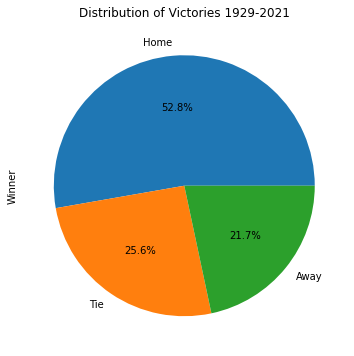

```python
df["goals_home"] = df["score"].str.split(":").str[0].astype(float)
df["goals_away"] = df["score"].str.split(":").str[1].astype(float)

conditions = [
    df['goals_home'] > df['goals_away'],
    df['goals_home'] < df['goals_away'],
    df['goals_home'] == df['goals_away']]
choices = ['Home', 'Away', 'Tie']

df['Winner'] = np.select(conditions, choices, default = 'unknown')
df = df[df['Winner']!='unknown']

winners_home_count = df['Winner'].value_counts()

fig = plt.figure(figsize=(6, 6))
ax = winners_home_count.plot(kind='pie', autopct='%1.1f%%')
ax.set_title("Distribution of Victories 1929-2021")
plt.show()
```

## 2a. Make two bar plot charts showing each of them. Consider only matches played in 1st division.

## What are the top ten scoring teams of all time? What are the ten teams that concede the most?

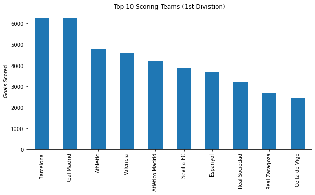

```python
df_1 = df[df['division']==1]

goals_home = df_1.groupby('home_team')['goals_home'].sum().sort_values(ascending=False) #home
goals_away = df_1.groupby('away_team')['goals_away'].sum().sort_values(ascending=False) #away
total_goals = goals_home.add(goals_away, fill_value=0)
top_10_goals = total_goals.sort_values(ascending=False).head(10)

plt.figure(figsize=[10,5])
ax = top_10_goals.plot.bar(top_10_goals.values, top_10_goals.index)
ax.set_title("Top 10 Scoring Teams (1st Divistion)")
plt.ylabel('Goals Scored')
plt.show()
```

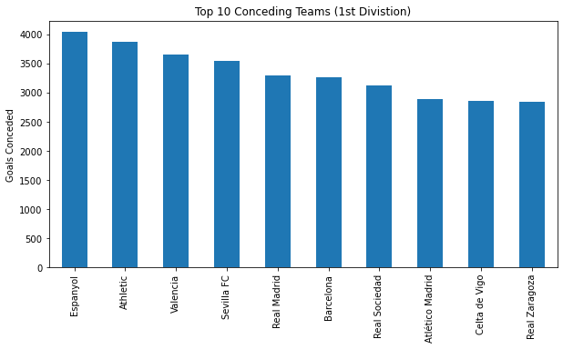

```python
df_1 = df[df['division']==1]

goals_home = df_1.groupby('home_team')['goals_away'].sum().sort_values(ascending=False) #home
goals_away = df_1.groupby('away_team')['goals_home'].sum().sort_values(ascending=False) #away
total_goals_conceded = goals_home.add(goals_away, fill_value=0)
top_10_goals_conceded = total_goals_conceded.sort_values(ascending=False).head(10)

plt.figure(figsize=[10,5])
ax = top_10_goals_conceded.plot.bar(top_10_goals_conceded.values, top_10_goals_conceded.index)
ax.set_title("Top 10 Conceding Teams (1st Divistion)")
plt.ylabel('Goals Conceded')
plt.show()
```

## 2b. What have been the biggest wins? Of course, when we say biggest we mean those with the highest goal difference. Show the top ten of them in a table.

```python
#If we understand the biggest wins in MATCHES (meaning, games that have presented the
#highest goal difference

df_1['goal_diff'] = np.abs(df_1['goals_home']-df_1['goals_away'])
Top_10_Victories = df_1.sort_values(by=['goal_diff'], ascending = False).head(10)
#But until position 23 matches have a difference of 9 goals.
Top_10_Victories
```

|  | season | division | matchday | date | time | home_team | away_team | score | goals_home | goals_away | Winner | goal_diff |
| --- | --- | --- | --- | --- | --- | --- | --- | --- | --- | --- | --- | --- |
| 225 | 1930-1931 | 1 | 10 | 2/8/31 | None | Athletic | Barcelona | 12:1 | 12.0 | 1.0 | Home | 11.0 |
| 936 | 1940-1941 | 1 | 1 | 9/29/40 | None | Sevilla FC | Barcelona | 11:1 | 11.0 | 1.0 | Home | 10.0 |
| 2787 | 1950-1951 | 1 | 11 | 11/19/50 | None | Athletic | Lérida | 10:0 | 10.0 | 0.0 | Home | 10.0 |
| 1168 | 1941-1942 | 1 | 15 | 1/11/42 | None | Athletic | Celta de Vigo | 10:0 | 10.0 | 0.0 | Home | 10.0 |
| 1071 | 1941-1942 | 1 | 1 | 9/28/41 | None | Sevilla FC | Real Oviedo | 10:0 | 10.0 | 0.0 | Home | 10.0 |
| 3629 | 1953-1954 | 1 | 26 | 3/28/54 | None | Barcelona | Real Oviedo | 9:0 | 9.0 | 0.0 | Home | 9.0 |
| 10024 | 1978-1979 | 1 | 16 | 1/14/79 | None | Barcelona | Rayo Vallecano | 9:0 | 9.0 | 0.0 | Home | 9.0 |
| 408 | 1932-1933 | 1 | 10 | 1/29/33 | None | Racing | Alavés | 9:0 | 9.0 | 0.0 | Home | 9.0 |
| 5027 | 1959-1960 | 1 | 21 | 2/7/60 | None | Real Madrid | Elche CF | 11:2 | 11.0 | 2.0 | Home | 9.0 |
| 3911 | 1955-1956 | 1 | 1 | 9/11/55 | None | Atlético Madrid | Hércules CF | 9:0 | 9.0 | 0.0 | Home | 9.0 |

```python
#If we understand the biggest wins in TEAMS (meaning, the teams that present the highest
#difference between goals scored and conceded
total_goal_difference=total_goals-total_goals_conceded
Top_10_Winners = {'Goals Scored': total_goals, 'Goals Conceded': total_goals_conceded, 'Goal difference': total_goal_difference}
Top_10_Winners = pd.DataFrame(Top_10_Winners)
Top_10_Winners = Top_10_Winners.sort_values(by='Goal difference', ascending=False).head(10)
Top_10_Winners
```

|  | Goals Scored | Goals Conceded | Goal difference |
| --- | --- | --- | --- |
| Barcelona | 6267.0 | 3259.0 | 3008.0 |
| Real Madrid | 6249.0 | 3287.0 | 2962.0 |
| Atlético Madrid | 4184.0 | 2894.0 | 1290.0 |
| Valencia | 4615.0 | 3649.0 | 966.0 |
| Athletic | 4802.0 | 3875.0 | 927.0 |
| Sevilla FC | 3903.0 | 3546.0 | 357.0 |
| Villarreal | 1123.0 | 986.0 | 137.0 |
| Real Sociedad | 3200.0 | 3126.0 | 74.0 |
| Atl. Aviación | 324.0 | 270.0 | 54.0 |
| Ath. Aviación | 113.0 | 65.0 | 48.0 |

## 3. There has been a lot of discussion about how LaLiga’s television rights have changed game schedules in the last years. Make a bar plot chart showing the number of matches played each weekday, and make also a histogram of match time. Compare this two graphics between seasons 2000-2001 and 2020-2021.

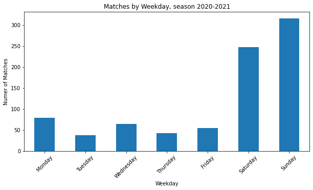

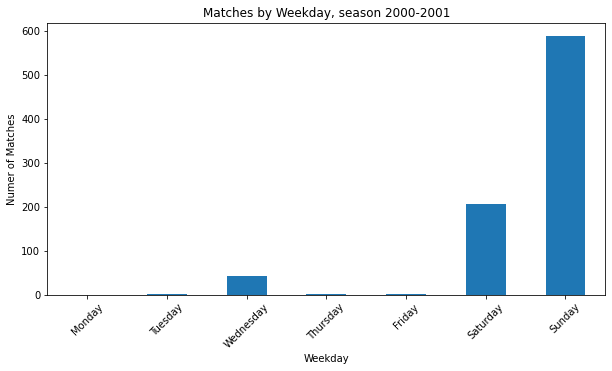

```python
df['data'] = df['season'].str.split("-").str[0].astype(int)//100*100 + df['date'].str.split("/").str[2].astype(int)
df['data'] = df['data'].replace(1900, 2000)
df['data'] = df['data'].astype(str) + "-" + df['date'].str.split("/").str[0].astype(str) + "-" + df['date'].str.split("/").str[1].astype(str)
df['data'] = pd.to_datetime(df['data'])
df['weekday'] = df['data'].dt.day_name()
df['weekday'] = pd.Categorical(df['weekday'], categories=
    ['Monday','Tuesday','Wednesday','Thursday','Friday','Saturday', 'Sunday'],
    ordered=True)

df_21 = df[df['season']=='2020-2021']

matches_by_day = df_21['weekday'].value_counts().sort_index()
plt.figure(figsize=[10,5])
ax = matches_by_day.plot(kind='bar')
plt.xlabel('Weekday')
plt.xticks(rotation=45)
plt.ylabel('Numer of Matches')
plt.title('Matches by Weekday, season 2020-2021')
plt.show()

df_01 = df[df['season']=='2000-2001']

matches_by_day = df_01['weekday'].value_counts().sort_index()
plt.figure(figsize=[10,5])
ax = matches_by_day.plot(kind='bar')
plt.xlabel('Weekday')
plt.xticks(rotation=45)
plt.ylabel('Numer of Matches')
plt.title('Matches by Weekday, season 2000-2001')
plt.show()
```

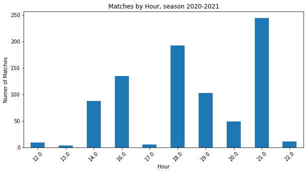

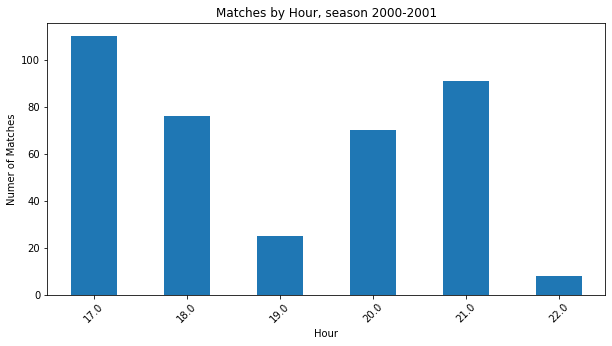

```python
df['Hour'] = pd.to_datetime(df['time'])
df['Hour'] = df['Hour'].dt.hour

df_21 = df[df['season']=='2020-2021']
df_01 = df[df['season']=='2000-2001']

matches_by_hour = df_21['Hour'].value_counts().sort_index()
plt.figure(figsize=[10,5])
ax = matches_by_hour.plot(kind='bar')
plt.xlabel('Hour')
plt.xticks(rotation=45)
plt.ylabel('Numer of Matches')
plt.title('Matches by Hour, season 2020-2021')
plt.show()


matches_by_hour = df_01['Hour'].value_counts().sort_index()
plt.figure(figsize=[10,5])
ax = matches_by_hour.plot(kind='bar')
plt.xlabel('Hour')
plt.xticks(rotation=45)
plt.ylabel('Numer of Matches')
plt.title('Matches by Hour, season 2000-2001')
plt.show()
```

## 4a. Build a cross results table for season 2020-2021 (1st division). Figure 1 is an example taken from Wikipedia. Try to make it the most similar to this one: use team abbreviations as column names and paint the background of each cell according to result (green in case local team wins and red in case visitor team wins). Also, could you model the intensity of this background color with the goal difference from the match?

```python
df_21 = df_21[df_21['division'] == 1]
cross = pd.crosstab(df_21.home_team, columns = df_21.away_team, values = df_21.score, aggfunc = 'first').fillna('-')
cross.rename(columns = {'Alavés':'ALA', 'Athletic':'ATH', 'Atlético Madrid':'ATL','Barcelona':'BAR', 'CA Osasuna':'OSA', 'Celta de Vigo':'CEL', 'Cádiz CF':'CAD', 'Elche CF':'ELC','Getafe':'GET', 'Granada CF':'GRA', 'Levante':'LEV', 'Real Betis':'BET', 'Real Madrid':'RMA', 'Real Sociedad':'RSC', 'Real Valladolid':'RVA', 'SD Eibar':'EIB', 'SD Huesca':'HUE', 'Sevilla FC':'SEV', 'Valencia':'VAL', 'Villarreal':'VIL'}, inplace = True)
```

```python
#background function, constant intensity
def background_constant(cell_value):

    default = ''
    if cell_value == '-': return default

    home = int(cell_value.split(":")[0])
    away = int(cell_value.split(":")[1])

    score = home-away

    win = 'background-color: lightgreen; '
    lose = 'background-color: salmon;'
    tie = 'background-color: yellow;'

    if score > 0: return win
    if score < 0: return lose
    if score == 0: return tie
    return default

cross.style.applymap(background_constant)
```

| away_team home_team | ALA | ATH | ATL | BAR | OSA | CEL | CAD | ELC | GET | GRA | LEV | BET | RMA | RSC | RVA | EIB | HUE | SEV | VAL | VIL |
| --- | --- | --- | --- | --- | --- | --- | --- | --- | --- | --- | --- | --- | --- | --- | --- | --- | --- | --- | --- | --- |
| Alavés | - | 1:0 | 1:2 | 1:1 | 0:1 | 1:3 | 1:1 | 0:2 | 0:0 | 4:2 | 2:2 | 0:1 | 1:4 | 0:0 | 1:0 | 2:1 | 1:0 | 1:2 | 2:2 | 2:1 |
| Athletic | 0:0 | - | 2:1 | 2:3 | 2:2 | 0:2 | 0:1 | 1:0 | 5:1 | 2:1 | 2:0 | 4:0 | 0:1 | 0:1 | 2:2 | 1:1 | 2:0 | 2:1 | 1:1 | 1:1 |
| Atlético Madrid | 1:0 | 2:1 | - | 1:0 | 2:1 | 2:2 | 4:0 | 3:1 | 1:0 | 6:1 | 0:2 | 2:0 | 1:1 | 2:1 | 2:0 | 5:0 | 2:0 | 2:0 | 3:1 | 0:0 |
| Barcelona | 5:1 | 2:1 | 0:0 | - | 4:0 | 1:2 | 1:1 | 3:0 | 5:2 | 1:2 | 1:0 | 5:2 | 1:3 | 2:1 | 1:0 | 1:1 | 4:1 | 1:1 | 2:2 | 4:0 |
| CA Osasuna | 1:1 | 1:0 | 1:3 | 0:2 | - | 2:0 | 3:2 | 2:0 | 0:0 | 3:1 | 1:3 | 0:2 | 0:0 | 0:1 | 0:0 | 2:1 | 1:1 | 0:2 | 3:1 | 1:3 |
| Celta de Vigo | 2:0 | 0:0 | 0:2 | 0:3 | 2:1 | - | 4:0 | 3:1 | 1:0 | 3:1 | 2:0 | 2:3 | 1:3 | 1:4 | 1:1 | 1:1 | 2:1 | 3:4 | 2:1 | 0:4 |
| Cádiz CF | 3:1 | 0:4 | 2:4 | 2:1 | 0:2 | 0:0 | - | 1:3 | 0:2 | 1:1 | 2:2 | 0:1 | 0:3 | 0:1 | 0:0 | 1:0 | 2:1 | 1:3 | 2:1 | 0:0 |
| Elche CF | 0:2 | 2:0 | 0:1 | 0:2 | 2:2 | 1:1 | 1:1 | - | 1:3 | 0:1 | 1:0 | 1:1 | 1:1 | 0:3 | 1:1 | 1:0 | 0:0 | 2:1 | 2:1 | 2:2 |
| Getafe | 0:0 | 1:1 | 0:0 | 1:0 | 1:0 | 1:1 | 0:1 | 1:1 | - | 0:1 | 2:1 | 3:0 | 0:0 | 0:1 | 0:1 | 0:1 | 1:0 | 0:1 | 3:0 | 1:3 |
| Granada CF | 2:1 | 2:0 | 1:2 | 0:4 | 2:0 | 0:0 | 0:1 | 2:1 | 0:0 | - | 1:1 | 2:0 | 1:4 | 1:0 | 1:3 | 4:1 | 3:3 | 1:0 | 2:1 | 0:3 |
| Levante | 1:1 | 1:1 | 1:1 | 3:3 | 0:1 | 1:1 | 2:2 | 1:1 | 3:0 | 2:2 | - | 4:3 | 0:2 | 2:1 | 2:2 | 2:1 | 0:2 | 0:1 | 1:0 | 1:5 |
| Real Betis | 3:2 | 0:0 | 1:1 | 2:3 | 1:0 | 2:1 | 1:0 | 3:1 | 1:0 | 2:1 | 2:0 | - | 2:3 | 0:3 | 2:0 | 0:2 | 1:0 | 1:1 | 2:2 | 1:1 |
| Real Madrid | 1:2 | 3:1 | 2:0 | 2:1 | 2:0 | 2:0 | 0:1 | 2:1 | 2:0 | 2:0 | 1:2 | 0:0 | - | 1:1 | 1:0 | 2:0 | 4:1 | 2:2 | 2:0 | 2:1 |
| Real Sociedad | 4:0 | 1:1 | 0:2 | 1:6 | 1:1 | 2:1 | 4:1 | 2:0 | 3:0 | 2:0 | 1:0 | 2:2 | 0:0 | - | 4:1 | 1:1 | 4:1 | 1:2 | 0:1 | 1:1 |
| Real Valladolid | 0:2 | 2:1 | 1:2 | 0:3 | 3:2 | 1:1 | 1:1 | 2:2 | 2:1 | 1:2 | 1:1 | 1:1 | 0:1 | 1:1 | - | 1:2 | 1:3 | 1:1 | 0:1 | 0:2 |
| SD Eibar | 3:0 | 1:2 | 1:2 | 0:1 | 0:0 | 0:0 | 0:2 | 0:1 | 0:0 | 2:0 | 0:1 | 1:1 | 1:3 | 0:1 | 1:1 | - | 1:1 | 0:2 | 0:0 | 1:3 |
| SD Huesca | 1:0 | 1:0 | 0:0 | 0:1 | 0:0 | 3:4 | 0:2 | 3:1 | 0:2 | 3:2 | 1:1 | 0:2 | 1:2 | 1:0 | 2:2 | 1:1 | - | 0:1 | 0:0 | 0:0 |
| Sevilla FC | 1:0 | 0:1 | 1:0 | 0:2 | 1:0 | 4:2 | 3:0 | 2:0 | 3:0 | 2:1 | 1:0 | 1:0 | 0:1 | 3:2 | 1:1 | 0:1 | 1:0 | - | 1:0 | 2:0 |
| Valencia | 1:1 | 2:2 | 0:1 | 2:3 | 1:1 | 2:0 | 1:1 | 1:0 | 2:2 | 2:1 | 4:2 | 0:2 | 4:1 | 2:2 | 3:0 | 4:1 | 1:1 | 0:1 | - | 2:1 |
| Villarreal | 3:1 | 1:1 | 0:2 | 1:2 | 1:2 | 2:4 | 2:1 | 0:0 | 1:0 | 2:2 | 2:1 | 1:2 | 1:1 | 1:1 | 2:0 | 2:1 | 1:1 | 4:0 | 2:1 | - |

```python
def background_modulat(cell_value):

    default = ''
    if cell_value == '-': return default

    home = int(cell_value.split(":")[0])
    away = int(cell_value.split(":")[1])

    score = home-away

    opacity = abs(score)*0.2

    win = 'background-color: lightgreen; opacity: ' + str(opacity)
    lose = 'background-color: salmon; opacity:' + str(opacity)
    tie = 'background-color: yellow; opacity: 0.3'

    if score > 0: return win
    if score < 0: return lose
    if score == 0: return tie
    return default

cross.style.applymap(background_modulat)
```

| away_team home_team | ALA | ATH | ATL | BAR | OSA | CEL | CAD | ELC | GET | GRA | LEV | BET | RMA | RSC | RVA | EIB | HUE | SEV | VAL | VIL |
| --- | --- | --- | --- | --- | --- | --- | --- | --- | --- | --- | --- | --- | --- | --- | --- | --- | --- | --- | --- | --- |
| Alavés | - | 1:0 | 1:2 | 1:1 | 0:1 | 1:3 | 1:1 | 0:2 | 0:0 | 4:2 | 2:2 | 0:1 | 1:4 | 0:0 | 1:0 | 2:1 | 1:0 | 1:2 | 2:2 | 2:1 |
| Athletic | 0:0 | - | 2:1 | 2:3 | 2:2 | 0:2 | 0:1 | 1:0 | 5:1 | 2:1 | 2:0 | 4:0 | 0:1 | 0:1 | 2:2 | 1:1 | 2:0 | 2:1 | 1:1 | 1:1 |
| Atlético Madrid | 1:0 | 2:1 | - | 1:0 | 2:1 | 2:2 | 4:0 | 3:1 | 1:0 | 6:1 | 0:2 | 2:0 | 1:1 | 2:1 | 2:0 | 5:0 | 2:0 | 2:0 | 3:1 | 0:0 |
| Barcelona | 5:1 | 2:1 | 0:0 | - | 4:0 | 1:2 | 1:1 | 3:0 | 5:2 | 1:2 | 1:0 | 5:2 | 1:3 | 2:1 | 1:0 | 1:1 | 4:1 | 1:1 | 2:2 | 4:0 |
| CA Osasuna | 1:1 | 1:0 | 1:3 | 0:2 | - | 2:0 | 3:2 | 2:0 | 0:0 | 3:1 | 1:3 | 0:2 | 0:0 | 0:1 | 0:0 | 2:1 | 1:1 | 0:2 | 3:1 | 1:3 |
| Celta de Vigo | 2:0 | 0:0 | 0:2 | 0:3 | 2:1 | - | 4:0 | 3:1 | 1:0 | 3:1 | 2:0 | 2:3 | 1:3 | 1:4 | 1:1 | 1:1 | 2:1 | 3:4 | 2:1 | 0:4 |
| Cádiz CF | 3:1 | 0:4 | 2:4 | 2:1 | 0:2 | 0:0 | - | 1:3 | 0:2 | 1:1 | 2:2 | 0:1 | 0:3 | 0:1 | 0:0 | 1:0 | 2:1 | 1:3 | 2:1 | 0:0 |
| Elche CF | 0:2 | 2:0 | 0:1 | 0:2 | 2:2 | 1:1 | 1:1 | - | 1:3 | 0:1 | 1:0 | 1:1 | 1:1 | 0:3 | 1:1 | 1:0 | 0:0 | 2:1 | 2:1 | 2:2 |
| Getafe | 0:0 | 1:1 | 0:0 | 1:0 | 1:0 | 1:1 | 0:1 | 1:1 | - | 0:1 | 2:1 | 3:0 | 0:0 | 0:1 | 0:1 | 0:1 | 1:0 | 0:1 | 3:0 | 1:3 |
| Granada CF | 2:1 | 2:0 | 1:2 | 0:4 | 2:0 | 0:0 | 0:1 | 2:1 | 0:0 | - | 1:1 | 2:0 | 1:4 | 1:0 | 1:3 | 4:1 | 3:3 | 1:0 | 2:1 | 0:3 |
| Levante | 1:1 | 1:1 | 1:1 | 3:3 | 0:1 | 1:1 | 2:2 | 1:1 | 3:0 | 2:2 | - | 4:3 | 0:2 | 2:1 | 2:2 | 2:1 | 0:2 | 0:1 | 1:0 | 1:5 |
| Real Betis | 3:2 | 0:0 | 1:1 | 2:3 | 1:0 | 2:1 | 1:0 | 3:1 | 1:0 | 2:1 | 2:0 | - | 2:3 | 0:3 | 2:0 | 0:2 | 1:0 | 1:1 | 2:2 | 1:1 |
| Real Madrid | 1:2 | 3:1 | 2:0 | 2:1 | 2:0 | 2:0 | 0:1 | 2:1 | 2:0 | 2:0 | 1:2 | 0:0 | - | 1:1 | 1:0 | 2:0 | 4:1 | 2:2 | 2:0 | 2:1 |
| Real Sociedad | 4:0 | 1:1 | 0:2 | 1:6 | 1:1 | 2:1 | 4:1 | 2:0 | 3:0 | 2:0 | 1:0 | 2:2 | 0:0 | - | 4:1 | 1:1 | 4:1 | 1:2 | 0:1 | 1:1 |
| Real Valladolid | 0:2 | 2:1 | 1:2 | 0:3 | 3:2 | 1:1 | 1:1 | 2:2 | 2:1 | 1:2 | 1:1 | 1:1 | 0:1 | 1:1 | - | 1:2 | 1:3 | 1:1 | 0:1 | 0:2 |
| SD Eibar | 3:0 | 1:2 | 1:2 | 0:1 | 0:0 | 0:0 | 0:2 | 0:1 | 0:0 | 2:0 | 0:1 | 1:1 | 1:3 | 0:1 | 1:1 | - | 1:1 | 0:2 | 0:0 | 1:3 |
| SD Huesca | 1:0 | 1:0 | 0:0 | 0:1 | 0:0 | 3:4 | 0:2 | 3:1 | 0:2 | 3:2 | 1:1 | 0:2 | 1:2 | 1:0 | 2:2 | 1:1 | - | 0:1 | 0:0 | 0:0 |
| Sevilla FC | 1:0 | 0:1 | 1:0 | 0:2 | 1:0 | 4:2 | 3:0 | 2:0 | 3:0 | 2:1 | 1:0 | 1:0 | 0:1 | 3:2 | 1:1 | 0:1 | 1:0 | - | 1:0 | 2:0 |
| Valencia | 1:1 | 2:2 | 0:1 | 2:3 | 1:1 | 2:0 | 1:1 | 1:0 | 2:2 | 2:1 | 4:2 | 0:2 | 4:1 | 2:2 | 3:0 | 4:1 | 1:1 | 0:1 | - | 2:1 |
| Villarreal | 3:1 | 1:1 | 0:2 | 1:2 | 1:2 | 2:4 | 2:1 | 0:0 | 1:0 | 2:2 | 2:1 | 1:2 | 1:1 | 1:1 | 2:0 | 2:1 | 1:1 | 4:0 | 2:1 | - |

## 4b. Write a function that, given the season and division, plots the cross results table. Function prototype should be like plot_cross_results_table(season, division) and return the plot object.

```python
def plot_cross_results_table(season, division):
    #from IPython.display import display
    df_s = df[df['season'] == season]
    df_s = df_s[df_s['division'] == division]

    cross = pd.crosstab(df_s.home_team, columns = df_s.away_team, values = df_s.score, aggfunc = 'first').fillna('-')

    def background(cell_value):

        default = ''
        if cell_value == '-': return default

        home = int(cell_value.split(":")[0])
        away = int(cell_value.split(":")[1])

        score = home-away

        opacity = abs(score)*0.2

        win = 'background-color: lightgreen; opacity: ' + str(opacity)
        lose = 'background-color: salmon; opacity:' + str(opacity)
        tie = 'background-color: yellow; opacity: 0.3'

        if score > 0: return win
        if score < 0: return lose
        if score == 0: return tie
        return default
    cross = cross.style.applymap(background)
    return cross
```

```python
#Example: season: 2017-2018, division: 2
cross = plot_cross_results_table('2017-2018', 2)
cross
```

| away_team home_team | Albacete | Alcorcón | Barcelona B | CA Osasuna | CD Lugo | CD Numancia | CD Tenerife | CyD Leonesa | Cádiz CF | Córdoba CF | Gimnàstic | Granada CF | Lorca FC | Rayo Vallecano | Real Oviedo | Real Valladolid | Real Zaragoza | Reus Deportiu | SD Huesca | Sevilla Atl. | Sporting Gijón | UD Almería |
| --- | --- | --- | --- | --- | --- | --- | --- | --- | --- | --- | --- | --- | --- | --- | --- | --- | --- | --- | --- | --- | --- | --- |
| Albacete | - | 2:0 | 0:0 | 0:0 | 0:1 | 1:0 | 1:2 | 0:0 | 1:1 | 0:3 | 0:1 | 2:1 | 2:1 | 0:1 | 2:1 | 2:1 | 0:0 | 0:1 | 0:0 | 2:1 | 2:2 | 2:0 |
| Alcorcón | 1:0 | - | 1:1 | 0:0 | 0:1 | 0:1 | 1:1 | 0:0 | 1:0 | 1:2 | 1:0 | 1:2 | 1:1 | 4:0 | 2:0 | 0:0 | 1:1 | 3:0 | 1:1 | 0:0 | 0:0 | 2:0 |
| Barcelona B | 0:1 | 0:1 | - | 0:2 | 1:2 | 2:2 | 0:3 | 0:1 | 3:1 | 4:0 | 1:1 | 3:0 | 1:0 | 2:3 | 1:1 | 0:1 | 0:2 | 0:1 | 0:2 | 1:1 | 2:1 | 1:1 |
| CA Osasuna | 1:0 | 2:3 | 2:2 | - | 1:1 | 2:2 | 0:1 | 2:1 | 1:0 | 1:1 | 0:2 | 0:0 | 1:0 | 1:1 | 2:1 | 4:2 | 1:2 | 0:0 | 1:1 | 1:1 | 2:0 | 2:1 |
| CD Lugo | 1:1 | 2:1 | 1:2 | 1:0 | - | 0:1 | 1:0 | 3:1 | 0:1 | 2:0 | 1:0 | 2:1 | 1:1 | 1:2 | 0:1 | 0:0 | 2:1 | 0:0 | 0:2 | 1:0 | 3:1 | 1:1 |
| CD Numancia | 5:1 | 1:0 | 1:0 | 1:1 | 2:0 | - | 2:0 | 2:1 | 1:0 | 2:1 | 1:2 | 1:3 | 1:0 | 0:0 | 3:0 | 0:1 | 1:2 | 1:0 | 1:0 | 3:0 | 3:0 | 1:0 |
| CD Tenerife | 1:1 | 4:0 | 1:3 | 0:0 | 3:1 | 1:1 | - | 2:0 | 1:1 | 5:1 | 2:0 | 2:2 | 2:0 | 2:2 | 3:1 | 0:0 | 1:0 | 3:0 | 2:4 | 2:0 | 1:0 | 0:0 |
| CyD Leonesa | 0:0 | 2:2 | 1:1 | 2:1 | 1:1 | 2:2 | 3:2 | - | 0:1 | 2:1 | 2:0 | 1:1 | 2:1 | 2:3 | 2:0 | 4:4 | 0:1 | 2:0 | 3:2 | 2:1 | 0:2 | 0:0 |
| Cádiz CF | 2:0 | 0:0 | 3:1 | 0:2 | 1:1 | 0:0 | 1:1 | 2:2 | - | 2:0 | 2:0 | 1:0 | 0:0 | 0:0 | 2:1 | 1:0 | 2:0 | 1:0 | 1:1 | 4:1 | 0:0 | 0:0 |
| Córdoba CF | 1:0 | 3:0 | 1:2 | 0:1 | 1:0 | 1:1 | 2:0 | 2:2 | 1:2 | - | 1:5 | 1:2 | 1:0 | 2:2 | 1:1 | 2:1 | 1:2 | 5:0 | 2:4 | 3:0 | 3:0 | 2:0 |
| Gimnàstic | 3:1 | 0:3 | 0:0 | 0:2 | 3:0 | 0:0 | 1:2 | 5:3 | 0:0 | 0:2 | - | 2:0 | 0:2 | 2:0 | 1:2 | 1:0 | 0:2 | 1:2 | 1:2 | 2:1 | 0:4 | 0:1 |
| Granada CF | 0:0 | 2:0 | 2:2 | 1:1 | 2:0 | 1:0 | 2:1 | 3:3 | 2:1 | 3:1 | 0:1 | - | 4:1 | 0:2 | 2:0 | 1:0 | 2:1 | 1:0 | 2:0 | 1:2 | 2:1 | 3:2 |
| Lorca FC | 1:2 | 1:1 | 1:1 | 0:1 | 1:2 | 2:1 | 2:2 | 2:0 | 3:0 | 1:0 | 1:0 | 3:2 | - | 0:0 | 0:2 | 1:5 | 0:2 | 1:1 | 2:3 | 2:1 | 0:0 | 1:2 |
| Rayo Vallecano | 1:1 | 2:1 | 1:0 | 0:3 | 1:0 | 2:2 | 3:1 | 3:1 | 1:1 | 1:2 | 2:3 | 1:0 | 5:1 | - | 2:2 | 4:1 | 2:1 | 3:2 | 3:0 | 2:0 | 1:1 | 1:0 |
| Real Oviedo | 0:0 | 0:1 | 0:0 | 1:0 | 3:2 | 3:1 | 1:1 | 3:0 | 1:0 | 2:0 | 1:0 | 2:1 | 2:0 | 2:3 | - | 1:2 | 2:2 | 3:0 | 2:1 | 2:1 | 2:1 | 2:1 |
| Real Valladolid | 3:2 | 4:0 | 1:2 | 2:0 | 2:2 | 2:3 | 2:0 | 3:2 | 1:1 | 4:1 | 0:3 | 2:1 | 3:0 | 1:1 | 3:1 | - | 3:2 | 1:0 | 3:2 | 1:0 | 0:1 | 2:1 |
| Real Zaragoza | 4:1 | 0:1 | 1:1 | 1:1 | 2:0 | 3:0 | 1:0 | 0:0 | 0:2 | 1:0 | 1:1 | 1:1 | 3:1 | 3:2 | 2:1 | 3:2 | - | 0:0 | 1:0 | 0:1 | 2:1 | 2:1 |
| Reus Deportiu | 1:1 | 1:1 | 2:1 | 0:0 | 0:1 | 1:0 | 1:1 | 1:1 | 1:0 | 1:2 | 1:1 | 0:0 | 3:0 | 0:2 | 0:0 | 2:2 | 1:1 | - | 0:0 | 2:0 | 1:0 | 1:0 |
| SD Huesca | 0:0 | 1:1 | 2:1 | 1:0 | 3:0 | 2:1 | 3:0 | 1:0 | 1:0 | 3:1 | 0:1 | 2:1 | 2:0 | 2:1 | 1:1 | 1:0 | 3:1 | 1:1 | - | 0:0 | 0:2 | 2:2 |
| Sevilla Atl. | 1:2 | 1:0 | 3:1 | 0:1 | 1:1 | 2:1 | 1:1 | 1:2 | 0:0 | 1:1 | 1:0 | 0:0 | 3:2 | 0:0 | 0:1 | 1:2 | 2:2 | 0:1 | 0:1 | - | 0:1 | 0:3 |
| Sporting Gijón | 2:1 | 3:0 | 2:3 | 2:0 | 2:0 | 2:0 | 3:0 | 4:0 | 0:3 | 3:2 | 2:0 | 2:1 | 1:0 | 1:0 | 1:1 | 1:1 | 0:1 | 2:1 | 1:1 | 3:0 | - | 2:0 |
| UD Almería | 1:1 | 0:0 | 1:0 | 0:1 | 1:0 | 0:0 | 2:1 | 2:1 | 0:2 | 1:0 | 1:1 | 2:0 | 2:1 | 0:1 | 1:1 | 1:1 | 3:0 | 0:1 | 0:3 | 3:0 | 1:3 | - |

## 5a. As you surely know, there has always been a historical rivalry between Barcelona and Real Madrid. But which of them has won the most games in direct confrontations? Which of them has scored the most goals in these games? Show both things in two pie charts, side by side. Remember to consider ties in the first one.

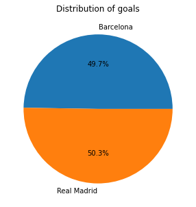

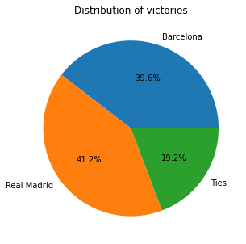

```python
team1 = 'Barcelona'
team2 = 'Real Madrid'

df_duel = df[(df['home_team']==team1) | (df['away_team']==team1)]
df_duel = df_duel[(df_duel['home_team']==team2) | (df_duel['away_team']==team2)]
df_duel['partits'] = 1

Rivals= df_duel.groupby(['home_team']).sum()
team1_goals  = df_duel.groupby(['home_team'])['goals_home'].sum()[0] + df_duel.groupby(['home_team'])['goals_away'].sum()[1]
team2_goals  = df_duel.groupby(['home_team'])['goals_home'].sum()[1] + df_duel.groupby(['home_team'])['goals_away'].sum()[0]
team1 = Rivals.index.values.tolist()[0]
team2 = Rivals.index.values.tolist()[1]
Rivals['total_home_goals'] = [team1_goals, team2_goals]


plt.figure(figsize = (5,5))
ax = Rivals['total_home_goals'].plot(kind='pie', autopct='%1.1f%%',ylabel='')
ax.set_title("Distribution of goals")
plt.show()

team1_wins =  df_duel.groupby(['Winner', 'home_team'])['partits'].count()[1] + df_duel.groupby(['Winner', 'home_team'])['partits'].count()[2]
team2_wins =  df_duel.groupby(['Winner', 'home_team'])['partits'].count()[0] + df_duel.groupby(['Winner', 'home_team'])['partits'].count()[3]
ties = df_duel.groupby(['Winner', 'home_team'])['partits'].count()[4] + df_duel.groupby(['Winner', 'home_team'])['partits'].count()[5]

plt.figure(figsize = (5,5))
plt.pie([team1_wins, team2_wins, ties], labels = [team1, team2, 'Ties'], autopct='%1.1f%%')
plt.title("Distribution of victories")
plt.show()
```

```python
def plot_direct_confrontations_stats(team1, team2):
    df_duel = df[(df['home_team']==team1) | (df['away_team']==team1)]
    df_duel = df_duel[(df_duel['home_team']==team2) | (df_duel['away_team']==team2)]
    df_duel['partits'] = 1

    Rivals= df_duel.groupby(['home_team']).sum()
    team1_goals  = df_duel.groupby(['home_team'])['goals_home'].sum()[0] + df_duel.groupby(['home_team'])['goals_away'].sum()[1]
    team2_goals  = df_duel.groupby(['home_team'])['goals_home'].sum()[1] + df_duel.groupby(['home_team'])['goals_away'].sum()[0]
    team1 = Rivals.index.values.tolist()[0]
    team2 = Rivals.index.values.tolist()[1]
    Rivals['total_home_goals'] = [team1_goals, team2_goals]


    plt.figure(figsize = (5,5))
    ax = Rivals['total_home_goals'].plot(kind='pie', autopct='%1.1f%%',ylabel='')
    ax.set_title("Distribution of goals")
    plt.show()

    team1_wins =  df_duel.groupby(['Winner', 'home_team'])['partits'].count()[1] + df_duel.groupby(['Winner', 'home_team'])['partits'].count()[2]
    team2_wins =  df_duel.groupby(['Winner', 'home_team'])['partits'].count()[0] + df_duel.groupby(['Winner', 'home_team'])['partits'].count()[3]
    ties = df_duel.groupby(['Winner', 'home_team'])['partits'].count()[4] + df_duel.groupby(['Winner', 'home_team'])['partits'].count()[5]

    plt.figure(figsize = (5,5))
    plt.pie([team1_wins, team2_wins, ties], labels = [team1, team2, 'Ties'], autopct='%1.1f%%')
    plt.title("Distribution of victories")
    plt.show()
```

```python
Teams = df.groupby('home_team').sum()
teams = Teams.index.values.tolist()
df_streak = pd.DataFrame()

for team in teams:
    df_team = pd.DataFrame()
    df_streak_team = pd.DataFrame()
    df_team = df[(df['home_team']==team) | (df['away_team']==team)]
    conditions = [
        ((df_team['Winner'] == 'Home') & (df_team['home_team']==team)) |
        ((df_team['Winner'] == 'Away') & (df_team['away_team']==team)) |
        (df_team['Winner'] == 'Tie')]
    choices = ['Yes']
    df_team = df_team.sort_values(by = 'data')

    df_team['team_wins'] = np.select(conditions, choices, default = 'No')
    df_team['start_of_streak'] = df_team.team_wins.ne(df_team['team_wins'].shift())
    df_team['streak_id'] = df_team['start_of_streak'].cumsum()
    df_team['streak_counter'] = df_team.groupby('streak_id').cumcount() + 1

    df_team = df_team.drop(df_team[df_team.team_wins == 'No'].index)

    df_streak_team['data'] = df_team['data']
    df_streak_team['streak_counter'] = df_team['streak_counter']
    df_streak_team['streak_team'] = team

    df_streak = df_streak.append(df_streak_team,ignore_index=True)

df_streak['start_of_streak'] = df_streak['streak_counter'] == 1
df_streak['end_of_streak'] = df_streak['start_of_streak'].shift(-1, fill_value=True)
df_streak.loc[df_streak['start_of_streak'], 'start_game'] = df_streak['data']
df_streak['start_game'] = df_streak['start_game'].fillna(method="ffill")
df_streak = df_streak[df_streak['end_of_streak']]
df_streak = df_streak.rename({"data": "end_game","streak_counter": "streak_length",}, axis=1)
```

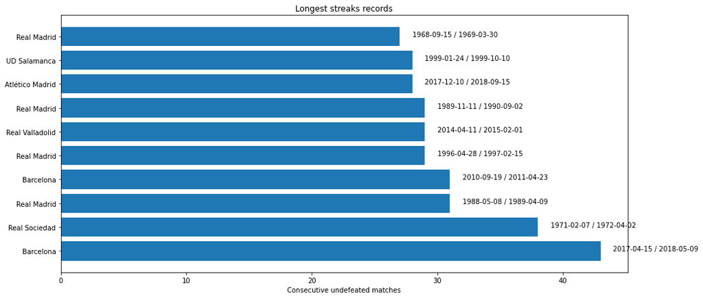

```python
df_streak['start_game'] = df_streak['start_game'].dt.date
df_streak['end_game'] = df_streak['end_game'].dt.date
df_streak = df_streak.sort_values(by = 'streak_length', ascending = False).head(10)

plt.figure(figsize = [15,7])
plt.barh(range(len(df_streak['streak_length'])), df_streak['streak_length'])
plt.yticks(range(len(df_streak['streak_length'])), df_streak['streak_team'])
plt.xlabel('Consecutive undefeated matches')
plt.title('Longest streaks records')

for i, team in enumerate(df_streak.index):
    start_game = df_streak.loc[team]['start_game']
    end_game = df_streak.loc[team]['end_game']
    plt.text(df_streak.loc[team]['streak_length']+1, i, f'{start_game} / {end_game}')

plt.show()
```

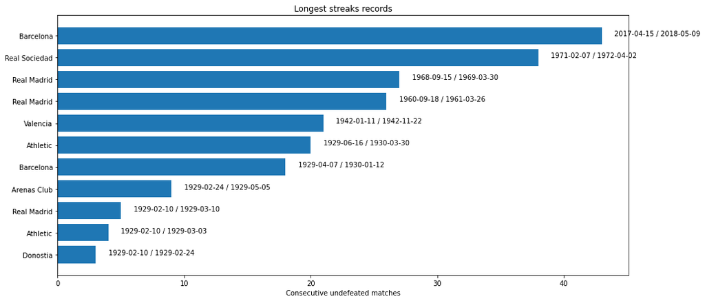

```python
#Here we plot only the streaks that were the maximum historical streaks in the moment

Teams = df.groupby('home_team').sum()
teams = Teams.index.values.tolist()
df_streak = pd.DataFrame()

for team in teams:
    df_team = pd.DataFrame()
    df_streak_team = pd.DataFrame()
    df_team = df[(df['home_team']==team) | (df['away_team']==team)]
    conditions = [
        ((df_team['Winner'] == 'Home') & (df_team['home_team']==team)) |
        ((df_team['Winner'] == 'Away') & (df_team['away_team']==team)) |
        (df_team['Winner'] == 'Tie')]
    choices = ['Yes']
    df_team = df_team.sort_values(by = 'data')

    df_team['team_wins'] = np.select(conditions, choices, default = 'No')
    df_team['start_of_streak'] = df_team.team_wins.ne(df_team['team_wins'].shift())
    df_team['streak_id'] = df_team['start_of_streak'].cumsum()
    df_team['streak_counter'] = df_team.groupby('streak_id').cumcount() + 1

    df_team = df_team.drop(df_team[df_team.team_wins == 'No'].index)

    df_streak_team['data'] = df_team['data']
    df_streak_team['streak_counter'] = df_team['streak_counter']
    df_streak_team['streak_team'] = team

    df_streak = df_streak.append(df_streak_team,ignore_index=True)

df_streak['start_of_streak'] = df_streak['streak_counter'] == 1
df_streak['end_of_streak'] = df_streak['start_of_streak'].shift(-1, fill_value=True)
df_streak.loc[df_streak['start_of_streak'], 'start_game'] = df_streak['data']
df_streak['start_game'] = df_streak['start_game'].fillna(method="ffill")
df_streak = df_streak[df_streak['end_of_streak']]
df_streak = df_streak.rename({"data": "end_game","streak_counter": "streak_length",}, axis=1)

df_streak = df_streak.sort_values(by = 'start_game')
df_streak['maxim_streak'] = df_streak['streak_length'].cummax()
df_streak = df_streak.drop_duplicates('maxim_streak')

df_streak['start_game'] = df_streak['start_game'].dt.date
df_streak['end_game'] = df_streak['end_game'].dt.date

plt.figure(figsize = [15,7])
plt.barh(range(len(df_streak['streak_length'])), df_streak['streak_length'])
plt.yticks(range(len(df_streak['streak_length'])), df_streak['streak_team'])
plt.xlabel('Consecutive undefeated matches')
plt.title('Longest streaks records')

for i, team in enumerate(df_streak.index):
    start_game = df_streak.loc[team]['start_game']
    end_game = df_streak.loc[team]['end_game']
    plt.text(df_streak.loc[team]['streak_length']+1, i, f'{start_game} / {end_game}')

plt.show()
```

## 7. Create a table with the final standings of each season (and division), that is, a table that contains all the teams ordered (in descending order) by the number of points they got during that season, and some other aggregate statistics.

```python
final_standings = pd.DataFrame(columns=['season', 'division', 'rank', 'team', 'GF', 'GA', 'GD', 'W', 'L', 'T', 'Pts'])
grouped_games = df.groupby(['season', 'division'])
for name, group in grouped_games:
    season, division = name
    teams = group['home_team'].unique()
    for team in teams:
        home_matches = group[group['home_team'] == team]
        away_matches = group[group['away_team'] == team]
        GF = home_matches['goals_home'].sum() + away_matches['goals_away'].sum()
        GA = home_matches['goals_away'].sum() + away_matches['goals_home'].sum()
        GD = GF - GA
        W = (home_matches['Winner'] == 'Home').sum() + (away_matches['Winner'] == 'Away').sum()
        L = (home_matches['Winner'] == 'Away').sum() + (away_matches['Winner'] == 'Home').sum()
        T = (home_matches['Winner'] == 'Tie').sum() + (away_matches['Winner'] == 'Tie').sum()
        Pts = 3*W+T
        heather = pd.DataFrame({'season': season, 'division': division, 'team': team, 'GF': GF, 'GA': GA, 'GD': GD, 'W': W, 'L': L, 'T': T, 'Pts': Pts}, index=[0])
        final_standings = pd.concat([final_standings, heather], ignore_index=True)
        final_standings = final_standings.sort_values(by=['season','division','Pts', 'GD', 'GF'], ascending=[False, True, False,False,False])
        final_standings['rank'] = final_standings.groupby(['season','division'])['Pts'].rank(method='first',ascending=False)
        final_standings['rank'] = final_standings['rank'].astype(int)
final_standings
```

|  | season | division | rank | team | GF | GA | GD | W | L | T | Pts |
| --- | --- | --- | --- | --- | --- | --- | --- | --- | --- | --- | --- |
| 0 | 2021-2022 | 1 | 1 | Valencia | 5.0 | 1.0 | 4.0 | 2 | 0 | 1 | 7 |
| 1 | 2021-2022 | 1 | 2 | Sevilla FC | 5.0 | 1.0 | 4.0 | 2 | 0 | 1 | 7 |
| 2 | 2021-2022 | 1 | 3 | Barcelona | 7.0 | 4.0 | 3.0 | 2 | 0 | 1 | 7 |
| 3 | 2021-2022 | 1 | 4 | Atlético Madrid | 5.0 | 3.0 | 2.0 | 2 | 0 | 1 | 7 |
| 4 | 2021-2022 | 1 | 5 | RCD Mallorca | 3.0 | 1.0 | 2.0 | 2 | 0 | 1 | 7 |
| ... | ... | ... | ... | ... | ... | ... | ... | ... | ... | ... | ... |
| 2779 | 1928-1929 | 1 | 6 | Athletic Madrid | 43.0 | 41.0 | 2.0 | 8 | 8 | 2 | 26 |
| 2780 | 1928-1929 | 1 | 7 | Espanyol | 32.0 | 38.0 | -6.0 | 7 | 7 | 4 | 25 |
| 2781 | 1928-1929 | 1 | 8 | Catalunya | 45.0 | 49.0 | -4.0 | 6 | 8 | 4 | 22 |
| 2782 | 1928-1929 | 1 | 9 | Real Unión | 40.0 | 42.0 | -2.0 | 5 | 11 | 2 | 17 |
| 2783 | 1928-1929 | 1 | 10 | Racing | 25.0 | 50.0 | -25.0 | 3 | 12 | 3 | 12 |

```python
final_standings.to_excel('SeasonStandings.xlsx', index=False)
```

## 8a. Villarreal is a team that has grown a lot in recent decades. Specially ever since some billionaire guy bought it (Fernando Roig, from Mercadona). Make a line plot showing the rank of Villarreal at the end of each season, from the oldest ones (left) to the earliest ones (right). Draw in the same plot a line showing the cut between 1st and 2nd division.

```python
villarreal = final_standings[final_standings['team'] == 'Villarreal']
division_cut=[]
for name, group in villarreal.groupby(['season', 'division']):
    season, division = name
    N = final_standings[(final_standings['season'] == season) & (final_standings['division'] == 1)]['team'].nunique()
    division_cut.append(N)
    if division == 1:
        villarreal.loc[group.index, 'ranked'] = group.loc[:,'rank']
    elif division == 2:
        villarreal.loc[group.index, 'ranked'] = group.loc[:, 'rank'] + N
villarreal=villarreal.sort_values(by=['season'], ascending=True)
```

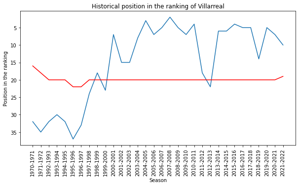

```python
plt.figure(figsize=[10,5])
plt.plot(villarreal['season'], villarreal['ranked'])
plt.gca().invert_yaxis()

plt.xlabel('Season')
plt.ylabel('Position in the ranking')
plt.title('Historical position in the ranking of Villarreal')

plt.plot(villarreal['season'], division_cut, color='red', linestyle='-')

plt.xticks(rotation=90)
plt.show()
```

## 8b. Write a function that, given n team names, plots the graph described above of each one of them superposed. Function prototype should be like plot_ranking_evolution(team1, team2, ..., teamN) and return the plot object (note that function should not take one array-type argument, but n arguments). Use it to compare the evolution of all the teams that currently play in 1st division.

```python
final_standings['first_season'] = final_standings.groupby('team')['season'].transform('min')
final_standings = final_standings.sort_values(by=['first_season', 'team'])

def plot_ranking_evolution(*teams):
    teams_df = final_standings[final_standings['team'].isin(teams)].copy()
    teams_df["first_season"] = teams_df.groupby("team")["season"].transform(min)
    teams_df = teams_df.sort_values(by=["first_season"])
    teams = teams_df["team"].unique()
    plt.figure(figsize=[20,7])
    for team in teams:
        team_standings = final_standings[final_standings['team'] == team].copy()
        grouped_standings = team_standings.groupby(['season', 'division'])
        for name, group in grouped_standings:
            season, division = name
            N = final_standings[(final_standings['season'] == season) & (final_standings['division'] == 1)]['team'].nunique()
            if division == 1:
                team_standings.loc[group.index, 'ranked'] = group.loc[:, 'rank']
            elif division == 2:
                team_standings.loc[group.index, 'ranked'] = group.loc[:, 'rank'] + N
            team_standings = team_standings.sort_values(by=['season'], ascending=True)
        plt.plot(team_standings['season'], team_standings['ranked'], label=team)
    plt.legend()
    plt.xticks(rotation=90)
    plt.gca().invert_yaxis()
    plt.show()
```

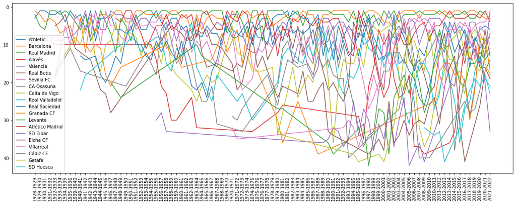

```python
teams_1st_division = final_standings[(final_standings['division'] == 1) & (final_standings['season']=='2020-2021')]['team'].unique()
plot_ranking_evolution(*teams_1st_division)
```